# Jakub Zbrzezny, nr albumu: 286689

# Nick do publikowania wyników: Heihachi46

# Praca domowa 1 - testy

## Implementacje wszystkich 4 metod.

### 1.Macierz najbliższych sąsiadów.

```python
# Jakub Zbrzezny, nr indeksu: 286689
# Nick do publikacji wyników: Heihachi46

# Algorytm spektralny i jego implementacja

# Ze wzgledu na indeksowanie od 0 przez Pythona, zakladam, ze skupienia
# i punkty numeruje sie od 0 do k - 1.

# 1) Macierz najblizszych sasiadow

import numpy as np


# Funkcja pomocnicza liczaca odleglosc wektorow.

def odleglosc_wektorow(x, y):
    assert len(x) == len(y), "Dlugosci wektorow x i y nie sa rowne!"
    return np.sqrt(sum([(a - b) ** 2 for a,b in zip(x, y)]))


def Mnn(X, M):
    if (type(X) != np.ndarray): raise Exception("X nie jest macierza!")
    # X.shape[0] jest liczba wierszy macierzy X.
    assert M % 1 == 0, "M nie jest calkowite!"
    assert M >= 1 and M <= X.shape[0], "M jest mniejsze od 1 lub M jest wieksze niz liczba wierszy macierzy X!"
    n = X.shape[0] # Liczba wierszy macierzy X.
    wsz_wiersze_S = [] # Bede po kolei dorzucac nowe wiersze do konstrukcji macierzy S.
    for i in range(n):
        odleglosci = np.linspace(0,0,n)
        wiersz_S = np.linspace(0,0,M) # W tej iteracji petli, tworze i-ty wiersz macierzy S.
        for j in range(n):
            odleglosci[j] = odleglosc_wektorow(X[i, ], X[j, ])
        # Chce uporzadkowac rosnaco odleglosci.
        posort_odleglosci = odleglosci
        posort_odleglosci = sorted(posort_odleglosci) # Funkcja sorted domyslnie sortuje rosnaco.
        for j in range(M):
            for k in range(n):
                # Sprawdzam, czy to jest indeks j-tego najblizszego sasiada x_i wzgledem metryki euklidesowej.
                if(odleglosci[k] == posort_odleglosci[j]):
                    wiersz_S[j] = k
        wsz_wiersze_S.append(wiersz_S) # Dorzucam nowy wiersz do macierzy S.
    S = np.array(wsz_wiersze_S)
    return S
```

### 2. Macierz sąsiedztwa.

```python
# 2) Macierz sasiedztwa

def Mnn_graph(S):
    if (type(S) != np.ndarray): raise Exception("S nie jest macierza!")
    n = S.shape[0]
    wsz_wiersze_Sas = []
    for i in range(n):
        wiersz_Sas = np.linspace(0, 0, n)
        for j in range(n):
            if any(S[i, ] == j) or any (S[j, ] == i):
                wiersz_Sas[j] = 1
            else:
                wiersz_Sas[j] = 0
        wsz_wiersze_Sas.append(wiersz_Sas)
    Sasiedzi = np.array(wsz_wiersze_Sas)
    return Sasiedzi
```

### 3. Laplasjan i jego wektory własne.

```python
# 3) Laplasjan i jego wektory wlasne

def Laplacian_eigen(G, k):
    n = G.shape[0] # G jest macierza kwadratowa, zatem wystarczy mi tylko liczba wierszy.
    assert k % 1 == 0, "k nie jest calkowite!"
    assert k > 1, "k musi byc wieksze od 1!"
    # Wyznaczam macierz D
    stopnie = []
    for i in range(n):
        suma = 0
        for j in range(n):
            if j == i: continue
            suma += G[i, j]
        stopnie.append(suma)
    D = np.diag(stopnie)
    L = D - G
    # np.linalg.eig(L) zwraca wektor, ktorego elementy sa wartosciami wlasnymi L
    # oraz macierz, ktorej kazdy wiersz jest wektorem wlasnym macierzy L.
    eig_vals, eig_vecs = np.linalg.eig(L)
    sort_eig_vals = eig_vals
    sort_eig_vals = sorted(sort_eig_vals)
    wiersze_E = []
    for i in range(1, k + 1):
        wekt_wl_do_E = []
        for j in range(n):
            if(eig_vals[j] == sort_eig_vals[i]):
                wekt_wl_do_E = eig_vecs[j]
                break
        wiersze_E.append(wekt_wl_do_E)
    E = np.array(wiersze_E)
    E = np.transpose(E) # Dokonalem transpozycji E, poniewaz np.array(wektor_1, ..., wektor_n)
    # tworzy macierz o wierszach wektor_1, ..., wektor_n, a w zadaniu kolumny maja byc wektorami
    # wlasnymi, a nie wiersze.
    return E
```

### 4. Funkcja spectral_clustering(X, k, M).

#### Użyłem pakietu igraph do algorytmu przeszukiwania w głąb (DFS).

```python
pip install python-igraph
```

```python
import igraph as ig
```

```python
# 4) Funkcja spectral_clustering(X, k, M).




def uspojnij(G): # Funkcja pomocnicza uspojniajaca graf sasiedztwa w przypadku, gdy graf nie jest spojny.
    # Szukam wszystkich skladowych spojnych za pomoca algorytmu przeszukiwania w głąb (DFS).
    # Jesli jest tylko jedna skladowa spojna, to znaczy, ze graf jest spojny.
    # Wtedy nie modyfikuje macierzy G.

    n = G.shape[0]

    graf = ig.Graph.Adjacency(G.tolist())


    # Sprawdzam, czy graf jest spojny.
    # graf.dfs(0)[0] zwraca wszystkie odwiedzone wierzcholki grafu "graf", rozpoczynajac od wierzcholka 0.
    if (len(graf.dfs(0)[0]) == n):
        return G

    # Uspojniam graf G.

    start = 0
    zbior = set(range(n)) # Jest to zbior wierzcholkow, z ktorego
    # jeszcze nie uzylem skladowych do uspojnienia grafu G.
    while not(len(graf.dfs(0)[0]) == n):
        wierz_skl = graf.dfs(start)[0]
        i = wierz_skl[0] # Moge polaczyc dowolny wierzcholek z jednej skladowej i dowolny z drugiej,
        # wiec wezme pierwszy wierzcholek z skladowej "wierz_skl".
        zbior = zbior.difference(wierz_skl)
        # Szukam wierzcholka spoza skladowej zmodyfikowanego grafu G i wczesniejszych
        # skladowych uzytych do uspojnienia grafu G.
        for j in range(n):
            if j in zbior:
                G[i, j] = 1 # Lacze wierzcholek i z wierzcholkiem spoza skladowej "wierz_skl".
                G[j, i] = 1 # Mam przypadek grafu nieskierowanego, zatem lacze wierzcholki w obie strony.
                start = j
                break
        graf = ig.Graph.Adjacency(G.tolist())

    return G

from sklearn.cluster import KMeans

def spectral_clustering(X, k, M):
    assert k >= 2, "k musi byc wieksze, badz rowne 2!!!"
    S = Mnn(X, M)
    G = Mnn_graph(S)

    # Uspojniam graf sasiedztwa, jesli graf nie jest spojny.


    G = uspojnij(G)


    E = Laplacian_eigen(G, k)



    k_podzial = KMeans(n_clusters = k).fit(E)

    return k_podzial
```

## Testy na różnych przykładach.

## 1 przykład

```python
X = np.eye(3)
X
```

```
array([[1., 0., 0.],
       [0., 1., 0.],
       [0., 0., 1.]])
```

```python
import mpl_toolkits.mplot3d as m3d
import matplotlib.pyplot as plt
```

```python
def rysuj_punkty(X):
    fig = plt.figure()
    ax = fig.add_subplot(111, projection = '3d')

    x = X[:, 0]
    y = X[:, 1]
    z = X[:, 2]

    ax.scatter(x, y, z, c = 'r', marker = 'o')

    ax.set_xlabel('x axis')
    ax.set_ylabel('y axis')
    ax.set_zlabel('z axis')

    plt.show()
```

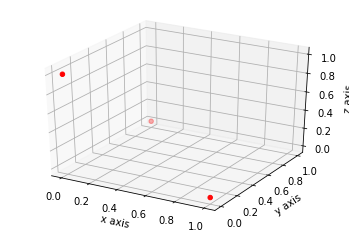

```python
rysuj_punkty(X)
```

#### 1.1. Macierz najbliższych sąsiadów.

```python
S = Mnn(X, 3)
S
```

```
array([[0., 2., 2.],
       [1., 2., 2.],
       [2., 1., 1.]])
```

#### 1.2. Macierz sąsiedztwa.

```python
G = Mnn_graph(S)
G
```

```
array([[1., 0., 1.],
       [0., 1., 1.],
       [1., 1., 1.]])
```

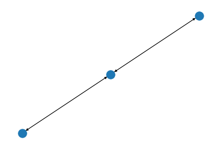

```python
import networkx as nx
graf = nx.DiGraph(G)
pos = nx.spring_layout(graf)
nx.draw(graf, pos)
```

Powyższy graf jest spójny.

#### 1.3. Laplasjan i jego wektory własne.

```python
E = Laplacian_eigen(G, 2)
E
```

```
array([[-0.40824829, -0.40824829],
       [ 0.70710678, -0.70710678],
       [ 0.57735027,  0.57735027]])
```

#### 1.4. spectral_clustering(X, k, M).

```python
k_podzial = spectral_clustering(G, 2, 3)
k_podzial.cluster_centers_
```

```
array([[ 0.49279928,  0.49279928],
       [-0.81618716,  0.38862863]])
```

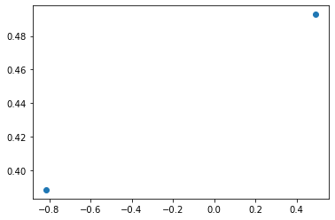

```python
x = k_podzial.cluster_centers_[:, 0]
y = k_podzial.cluster_centers_[:, 1]
plt.scatter(x,y)
```

### 2 przykład.

```python
X = np.array([[3, 4, 5],
              [1, 2, 3],
              [5, 6, 7],
              [10, 11, 5],
              [8, 6, 9]])
X
```

```
array([[ 3,  4,  5],
       [ 1,  2,  3],
       [ 5,  6,  7],
       [10, 11,  5],
       [ 8,  6,  9]])
```

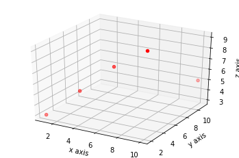

```python
rysuj_punkty(X)
```

#### 2.1. Macierz najbliższych sąsiadów.

```python
S = Mnn(X, 3)
S
```

```
array([[0., 2., 2.],
       [1., 0., 2.],
       [2., 0., 4.],
       [3., 4., 2.],
       [4., 2., 3.]])
```

#### 2.2. Macierz sąsiedztwa.

```python
G = Mnn_graph(S)
G
```

```
array([[1., 1., 1., 0., 0.],
       [1., 1., 1., 0., 0.],
       [1., 1., 1., 1., 1.],
       [0., 0., 1., 1., 1.],
       [0., 0., 1., 1., 1.]])
```

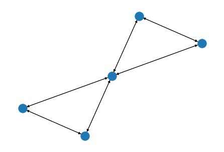

```python
graf = nx.DiGraph(G)
pos = nx.spring_layout(graf)
nx.draw(graf, pos)
```

Powyższy graf jest spójny.

#### 2.3. Laplasjan i jego wektory własne.

```python
E = Laplacian_eigen(G, 3)
E
```

```
array([[ 2.23606798e-01,  2.23606798e-01,  2.23606798e-01],
       [-8.74964484e-17,  7.07106781e-01, -4.41377076e-17],
       [-4.47213595e-01, -4.47213595e-01, -4.47213595e-01],
       [-5.00000000e-01,  5.00000000e-01, -5.00000000e-01],
       [-7.06508536e-01, -2.90807146e-02,  7.06508536e-01]])
```

#### 2.4. spectral_clustering(X, k, M).

```python
k_podzial = spectral_clustering(G, 3, 3)
k_podzial.cluster_centers_
```

```
array([[ 0.04719209,  0.41894012, -0.55729477],
       [-0.50347116, -0.50347116, -0.36625113],
       [-0.21525552,  0.38624543,  0.34603036]])
```

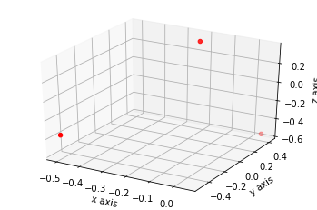

```python
rysuj_punkty(k_podzial.cluster_centers_)
```

### 3 przykład.

```python
np.random.seed(123)
X = np.random.normal(0, 10, 30).reshape(10, 3)
X
```

```
array([[-10.85630603,   9.97345447,   2.82978498],
       [-15.06294714,  -5.78600252,  16.51436537],
       [-24.26679243,  -4.28912629,  12.65936259],
       [ -8.66740402,  -6.78886152,  -0.94708969],
       [ 14.91389626,  -6.38901997,  -4.4398196 ],
       [ -4.34351276,  22.05930083,  21.86786089],
       [ 10.04053898,   3.86186399,   7.37368576],
       [ 14.90732028,  -9.35833868,  11.75829045],
       [-12.53880668,  -6.37751502,   9.07105196],
       [-14.286807  ,  -1.4006872 ,  -8.61754896]])
```

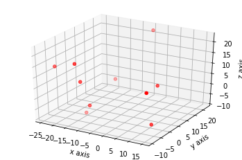

```python
rysuj_punkty(X)
```

#### 3.1. Macierz najbliższych sąsiadów.

```python
S = Mnn(X, 3)
S
```

```
array([[0., 9., 3.],
       [1., 8., 2.],
       [2., 1., 8.],
       [3., 8., 9.],
       [4., 6., 7.],
       [5., 0., 6.],
       [6., 7., 4.],
       [7., 6., 4.],
       [8., 1., 3.],
       [9., 3., 0.]])
```

#### 3.2. Macierz sąsiedztwa.

```python
G = Mnn_graph(S)
G
```

```
array([[1., 0., 0., 1., 0., 1., 0., 0., 0., 1.],
       [0., 1., 1., 0., 0., 0., 0., 0., 1., 0.],
       [0., 1., 1., 0., 0., 0., 0., 0., 1., 0.],
       [1., 0., 0., 1., 0., 0., 0., 0., 1., 1.],
       [0., 0., 0., 0., 1., 0., 1., 1., 0., 0.],
       [1., 0., 0., 0., 0., 1., 1., 0., 0., 0.],
       [0., 0., 0., 0., 1., 1., 1., 1., 0., 0.],
       [0., 0., 0., 0., 1., 0., 1., 1., 0., 0.],
       [0., 1., 1., 1., 0., 0., 0., 0., 1., 0.],
       [1., 0., 0., 1., 0., 0., 0., 0., 0., 1.]])
```

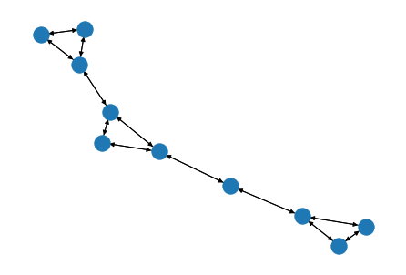

```python
graf = nx.DiGraph(G)
pos = nx.spring_layout(graf)
nx.draw(graf, pos)
```

Powyższy graf jest spójny.

#### 3.3. Laplasjan i jego wektory własne.

```python
E = Laplacian_eigen(G, 3)
E
```

```
array([[-2.14711493e-01,  5.78211835e-02,  6.00884938e-01],
       [-6.05969985e-01,  1.85056468e-01, -2.57624092e-01],
       [-5.56458294e-01,  2.08066478e-01, -1.83686011e-02],
       [ 1.71591735e-01, -2.68191311e-01, -2.43472173e-01],
       [-1.10459526e-01, -2.44050818e-01,  3.16430648e-01],
       [ 3.16227766e-01,  3.16227766e-01,  3.16227766e-01],
       [ 3.67978924e-01,  4.33164835e-01, -1.64646206e-01],
       [ 8.87902979e-18,  1.66880284e-02, -3.77053416e-01],
       [ 2.38434615e-16,  5.44125716e-01, -1.63721174e-01],
       [ 8.95525931e-17, -4.36508166e-01, -3.28508421e-01]])
```

#### 3.4. spectral_clustering(X, k, M).

```python
k_podzial = spectral_clustering(X, 3, 5)
k_podzial.cluster_centers_
```

```
array([[ 0.00516748,  0.17671939,  0.13305271],
       [-0.12995705, -0.183733  , -0.34570464],
       [-0.52434748, -0.10528171,  0.31014375]])
```

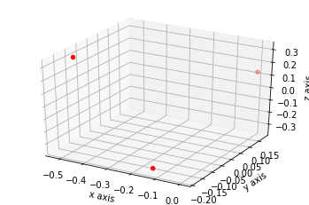

```python
rysuj_punkty(k_podzial.cluster_centers_)
```

### 4 przykład.

```python
np.random.seed(123)
X = np.random.uniform(-10, 10, 102).reshape(34, 3)
X
```

```
array([[ 3.92938371, -4.2772133 , -5.46297093],
       [ 1.02629538,  4.3893794 , -1.5378708 ],
       [ 9.61528397,  3.69659477, -0.38136197],
       [-2.15764964, -3.13643968,  4.58099415],
       [-1.22855511, -8.80644207, -2.03911489],
       [ 4.75990811, -6.35016539, -6.49096488],
       [ 0.63102748,  0.63655174,  2.68801917],
       [ 6.98863588,  4.4891065 ,  2.22047021],
       [ 4.44886765, -3.54082172, -2.76422689],
       [-5.43473538, -4.12571907,  2.61952248],
       [-8.1579012 , -1.32597655, -1.38274473],
       [-0.12629805, -1.48339419, -3.75477554],
       [-1.47297386,  7.86778326,  8.88320036],
       [ 0.03673352,  2.47905904, -7.6876321 ],
       [-3.65429036, -1.70347576,  7.32618316],
       [-4.99089269, -0.33931471,  9.71119571],
       [ 0.38970239,  2.25789052, -7.58742668],
       [ 6.52681601,  2.06120257,  0.90136013],
       [-3.14472332, -3.91758422, -1.65955578],
       [ 3.62601532,  7.50913684,  0.20844675],
       [ 3.38627566,  1.71873105,  2.49807004],
       [ 3.49378102,  6.84684875, -8.33610023],
       [ 5.27365683, -5.12667251, -6.11554079],
       [ 1.44913915, -8.08574967,  7.70653653],
       [ 2.54497944,  4.46832716, -9.67741587],
       [ 1.88863759,  1.13570385, -6.82080712],
       [-6.9385897 ,  3.91059058, -3.62467147],
       [ 3.83940591,  1.08766499, -2.22098852],
       [ 8.50264979,  6.83339994, -2.85204867],
       [-9.12817072, -3.90463853, -2.03628636],
       [ 4.09917661,  9.90716964, -2.88170269],
       [ 5.25095628,  1.86353833,  3.83403597],
       [-6.97745095, -2.02247415, -5.18288205],
       [-3.13087972,  0.26256308,  3.332491  ]])
```

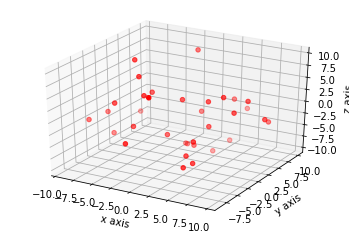

```python
rysuj_punkty(X)
```

#### 4.1. Macierz najbliższych sąsiadów.

```python
S = Mnn(X, 3)
S
```

```
array([[ 0., 22.,  5.],
       [ 1., 27., 19.],
       [ 2., 17.,  7.],
       [ 3., 14., 33.],
       [ 4., 18., 11.],
       [ 5., 22.,  0.],
       [ 6., 20., 33.],
       [ 7., 17., 31.],
       [ 8.,  0., 22.],
       [ 9.,  3., 18.],
       [10., 29., 32.],
       [11., 18., 25.],
       [12., 15., 33.],
       [13., 16., 25.],
       [14., 15.,  3.],
       [15., 14.,  3.],
       [16., 13., 25.],
       [17.,  7., 31.],
       [18., 11.,  9.],
       [19., 30.,  1.],
       [20., 31.,  6.],
       [21., 24., 16.],
       [22.,  5.,  0.],
       [23.,  3., 14.],
       [24., 21., 16.],
       [25., 16., 13.],
       [26., 10., 32.],
       [27., 17.,  1.],
       [28.,  2., 30.],
       [29., 10., 32.],
       [30., 19., 28.],
       [31., 20., 17.],
       [32., 10., 29.],
       [33.,  3.,  6.]])
```

#### 4.2. Macierz sąsiedztwa.

```python
G = Mnn_graph(S)
G
```

```
array([[1., 0., 0., ..., 0., 0., 0.],
       [0., 1., 0., ..., 0., 0., 0.],
       [0., 0., 1., ..., 0., 0., 0.],
       ...,
       [0., 0., 0., ..., 1., 0., 0.],
       [0., 0., 0., ..., 0., 1., 0.],
       [0., 0., 0., ..., 0., 0., 1.]])
```

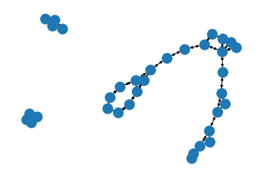

```python
graf = nx.DiGraph(G)
pos = nx.spring_layout(graf)
nx.draw(graf, pos)
```

Tym razem już graf nie jest spójny. Są 3 składowe spójne.

#### 4.3. Laplasjan i jego wektory własne.

```python
E = Laplacian_eigen(G, 3)
E
```

```
array([[ 0.00000000e+00,  0.00000000e+00,  0.00000000e+00],
       [ 0.00000000e+00,  0.00000000e+00,  0.00000000e+00],
       [-4.10765724e-18, -7.93663379e-03, -7.95999275e-02],
       [ 5.36089849e-19,  1.86627097e-03, -4.22605913e-02],
       [ 2.57710123e-18,  4.41670419e-01, -5.41251841e-03],
       [-3.01671607e-16,  1.76006825e-01, -1.83682899e-01],
       [ 8.95552914e-16, -2.47417391e-01,  5.83462634e-02],
       [ 4.95646960e-17, -2.66187018e-02,  2.44281230e-01],
       [-2.33982272e-17, -4.03526116e-02, -2.14040600e-01],
       [ 3.19703890e-17,  2.07349058e-02,  3.27733871e-01],
       [-1.45879045e-16,  2.51268309e-02,  3.66969186e-01],
       [ 5.11743986e-17, -4.10238482e-01,  4.46996312e-02],
       [ 3.49902268e-18,  6.78494933e-02,  1.21505067e-01],
       [-2.08783526e-16, -1.34179801e-02, -3.47646048e-02],
       [ 1.14454009e-16, -2.36132094e-03, -3.51887044e-01],
       [ 9.22586795e-18,  3.69157762e-03,  2.93362735e-01],
       [-8.64034764e-17,  9.07099272e-02, -1.04678487e-01],
       [ 2.04637407e-16, -2.76909944e-01,  2.27382614e-02],
       [-1.13652932e-17,  1.67743433e-01,  3.60589026e-02],
       [-1.40816905e-17, -2.32439690e-04,  1.22394956e-02],
       [-5.28068148e-17, -9.96447458e-03, -3.05495337e-01],
       [-8.15654085e-18, -3.58774076e-02,  9.02538795e-02],
       [-2.41726833e-16,  1.19332821e-01, -3.07189202e-01],
       [-1.08920593e-16, -2.96417914e-01,  5.75260205e-02],
       [ 2.41950778e-16,  1.76559238e-01,  3.58820591e-01],
       [-1.24437312e-16, -1.95107212e-01, -1.95107212e-01],
       [-4.92742516e-01,  3.30266670e-02,  3.30266670e-02],
       [ 1.10462290e-01, -1.37867605e-16, -8.72177424e-16],
       [-7.05930594e-01,  1.79688713e-17,  3.09093901e-17],
       [ 3.94041200e-16, -4.04848486e-01,  2.78452738e-16],
       [ 7.71823088e-16, -1.46313998e-01, -9.44291043e-16],
       [-1.49603535e-02,  6.56436138e-16,  1.55345182e-15],
       [-3.27172005e-01,  1.99214483e-15,  4.39488075e-15],
       [ 4.64403674e-01, -6.17730625e-16, -1.29689353e-15]])
```

#### 4.4. spectral_clustering(X, k, M).

```python
k_podzial = spectral_clustering(X, 3, 5)
k_podzial.cluster_centers_
```

```
array([[-0.07124867, -0.05074482, -0.01848523],
       [ 0.02089145,  0.06701565,  0.34476114],
       [ 0.1417214 ,  0.17329351, -0.17124779]])
```

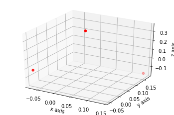

```python
rysuj_punkty(k_podzial.cluster_centers_)
```

### 5 przykład.

```python
np.random.seed(123)
X = np.random.geometric(0.3, 102).reshape(34, 3)
X
```

```
array([[ 4,  1,  1],
       [ 3,  4,  2],
       [12,  4,  2],
       [ 2,  2,  4],
       [ 2,  1,  2],
       [ 4,  1,  1],
       [ 3,  3,  3],
       [ 6,  4,  3],
       [ 4,  2,  2],
       [ 1,  1,  3],
       [ 1,  2,  2],
       [ 2,  2,  2],
       [ 2,  7,  9],
       [ 2,  3,  1],
       [ 2,  2,  6],
       [ 1,  2, 12],
       [ 3,  3,  1],
       [ 5,  3,  3],
       [ 2,  2,  2],
       [ 4,  6,  3],
       [ 4,  3,  3],
       [ 4,  6,  1],
       [ 5,  1,  1],
       [ 3,  1,  7],
       [ 3,  4,  1],
       [ 3,  3,  1],
       [ 1,  4,  2],
       [ 4,  3,  2],
       [ 8,  6,  2],
       [ 1,  2,  2],
       [ 4, 16,  2],
       [ 5,  3,  4],
       [ 1,  2,  1],
       [ 2,  3,  4]])
```

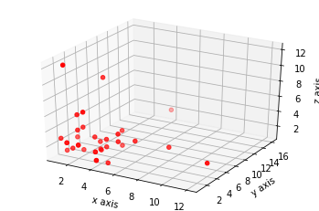

```python
rysuj_punkty(X)
```

#### 5.1. Macierz najbliższych sąsiadów.

```python
S = Mnn(X, 3)
S
```

```
array([[ 5.,  5., 22.],
       [ 1., 24., 27.],
       [ 2., 28.,  7.],
       [ 3., 33.,  9.],
       [ 4., 18., 18.],
       [ 5.,  5., 22.],
       [ 6., 20., 33.],
       [ 7., 17., 31.],
       [ 8., 27., 20.],
       [ 9., 29., 29.],
       [29., 29., 32.],
       [18., 18., 29.],
       [12., 14., 15.],
       [13., 25., 25.],
       [14., 23.,  3.],
       [15., 23., 12.],
       [25., 25., 24.],
       [17., 31., 31.],
       [18., 18., 29.],
       [19., 21.,  1.],
       [20., 27., 27.],
       [21., 19., 24.],
       [22.,  5.,  5.],
       [23., 14.,  3.],
       [24., 25., 25.],
       [25., 25., 24.],
       [26., 13., 29.],
       [27., 20., 20.],
       [28.,  7., 21.],
       [29., 29., 32.],
       [30., 21., 21.],
       [31., 17., 20.],
       [32., 29., 29.],
       [33.,  3.,  6.]])
```

#### 5.2. Macierz sąsiedztwa.

```python
G = Mnn_graph(S)
G
```

```
array([[0., 0., 0., ..., 0., 0., 0.],
       [0., 1., 0., ..., 0., 0., 0.],
       [0., 0., 1., ..., 0., 0., 0.],
       ...,
       [0., 0., 0., ..., 1., 0., 0.],
       [0., 0., 0., ..., 0., 1., 0.],
       [0., 0., 0., ..., 0., 0., 1.]])
```

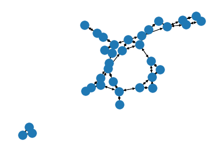

```python
graf = nx.DiGraph(G)
pos = nx.spring_layout(graf)
nx.draw(graf, pos)
```

Widzimy, że graf nie jest spójny. Są 2 składe spójne.

#### 5.3. Laplasjan i jego wektory własne.

```python
E = Laplacian_eigen(G, 3)
E
```

```
array([[ 0.00000000e+00,  0.00000000e+00,  0.00000000e+00],
       [ 0.00000000e+00,  0.00000000e+00,  0.00000000e+00],
       [ 1.52452785e-04, -1.09580655e-03, -1.88359621e-01],
       [ 3.28292785e-03,  3.10625392e-01, -4.13377487e-04],
       [-1.29781599e-01, -1.49210724e-02,  4.93447588e-02],
       [ 2.60988756e-02,  2.69749739e-02,  2.15103063e-01],
       [-2.89651488e-02,  2.41004131e-01, -4.19825918e-02],
       [ 2.28677230e-01,  1.90178034e-01,  1.35005346e-01],
       [ 1.05031870e-01,  1.29132612e-01, -1.77860254e-01],
       [ 6.48995988e-02, -4.25455433e-02, -1.33230868e-01],
       [ 1.41741040e-01, -1.70312661e-01,  4.84245048e-02],
       [ 3.99578018e-01,  1.83551387e-01,  5.87043468e-03],
       [ 7.81148828e-02,  1.02918449e-01, -5.94704590e-02],
       [ 1.84953710e-01,  1.66757406e-01, -2.61171508e-01],
       [-2.47144081e-01, -1.25399210e-01, -8.85769964e-02],
       [ 2.40394128e-01, -2.83165322e-01, -1.66991679e-01],
       [-2.56742164e-01,  9.45793601e-02,  6.64491581e-02],
       [-1.20756736e-01, -5.71955161e-02, -5.81109745e-01],
       [ 1.97815080e-01, -1.44149413e-01,  2.59939091e-01],
       [-1.37540151e-01, -2.49375139e-01, -4.10659180e-03],
       [ 1.58238121e-01,  2.70355295e-01,  1.73598637e-02],
       [-3.11819177e-01, -3.19505153e-01, -5.43154952e-03],
       [-3.47432743e-03, -5.14802583e-03, -8.72116477e-03],
       [-3.20099869e-03,  3.76420358e-04, -2.81800144e-02],
       [-1.57662145e-01, -7.10059563e-02, -3.95968236e-02],
       [-1.70520085e-01,  9.12659666e-02,  2.81125417e-03],
       [-3.48200170e-01,  3.68687037e-01,  5.93266762e-02],
       [ 3.60374040e-01, -2.96666511e-01,  2.72416858e-02],
       [ 1.60284844e-02,  2.90710900e-01, -6.09554077e-02],
       [-6.28664645e-02, -8.66229674e-03,  9.81205590e-02],
       [-7.11365594e-02, -2.30852620e-02,  5.53635892e-01],
       [ 1.52250942e-16,  5.92943041e-17,  1.13965607e-16],
       [-8.26707313e-17,  6.17507797e-16,  3.44451737e-16],
       [ 4.31445813e-16,  1.54802094e-16, -1.77931736e-15]])
```

#### 5.4. spectral_clustering(X, k, M).

```python
k_podzial = spectral_clustering(X, 3, 5)
k_podzial.cluster_centers_
```

```
array([[-0.06972724,  0.0039316 ,  0.56641994],
       [ 0.14966477, -0.16685789,  0.03704904],
       [-0.04498155,  0.06587209, -0.01534445]])
```

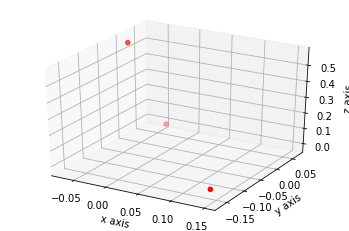

```python
rysuj_punkty(k_podzial.cluster_centers_)
```

## Testowanie funkcji uspójniającej graf niespójny "uspojnij(G)".

### 1 przykład.

```python
G = np.array([[1, 1, 1, 0, 0, 0, 0],
              [1, 1, 1, 0, 0, 0, 0],
              [1, 1, 1, 0, 0, 0, 0],
              [0, 0, 0, 1, 1, 0, 1],
              [0, 0, 0, 1, 1, 1, 0],
              [0, 0, 0, 0, 1, 1, 1],
              [0, 0, 0, 1, 0, 1, 1]])
```

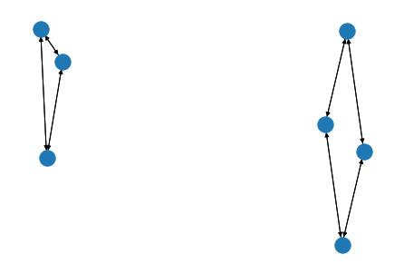

```python
graf = nx.DiGraph(G)
pos = nx.spring_layout(graf)
nx.draw(graf, pos)
```

Graf nie jest spójny. Mamy 2 składowe spójne. Uspójniam graf G moją funkcją.

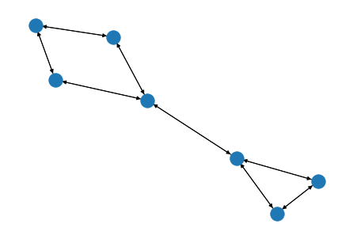

```python
G = uspojnij(G)
graf = nx.DiGraph(G)
pos = nx.spring_layout(graf)
nx.draw(graf, pos)
```

Widać więc, że graf został prawidłowo uspójniony i dodano minimalną ilość krawędzi potrzebną do uspójnienia grafu G (dokładnie 1 krawędź dodano). Zatem tu funkcja działa poprawnie.

### 2 przykład.

```python
G = np.array([[1, 1, 0, 0, 0, 0],
              [1, 1, 0, 0, 0, 0],
              [0, 0, 1, 1, 0, 0],
              [0, 0, 1, 1, 0, 0],
              [0, 0, 0, 0, 1, 1],
              [0, 0, 0, 0, 1, 1]])
```

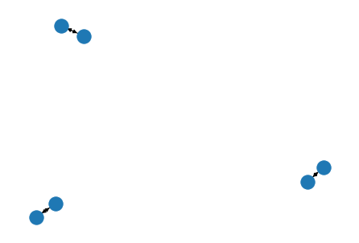

```python
graf = nx.DiGraph(G)
pos = nx.spring_layout(graf)
nx.draw(graf, pos)
```

Graf nie jest spójny, bo są 3 składowe spójne.

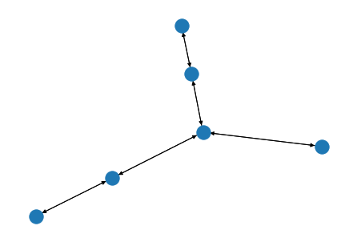

```python
G = uspojnij(G)
graf = nx.DiGraph(G)
pos = nx.spring_layout(graf)
nx.draw(graf, pos)
```

Tutaj też funkcja zadziałała poprawnie, gdyż otrzymałem graf spójny oraz dodano dokładnie 2 krawędzie do uspójnienia grafu G.

### 3 przykład.

```python
G = np.array([[1, 1, 1, 0, 0, 0, 0, 0, 0, 0],
             [1, 1, 1, 0, 0, 0, 0, 0, 0, 0],
             [1, 1, 1, 0, 0, 0, 0, 0, 0, 0],
             [0, 0, 0, 1, 1, 1, 0, 0, 0, 0],
             [0, 0, 0, 1, 1, 1, 0, 0, 0, 0],
             [0, 0, 0, 1, 1, 1, 0, 0, 0, 0],
             [0, 0, 0, 0, 0, 0, 1, 1, 0, 0],
             [0, 0, 0, 0, 0, 0, 1, 1, 0, 0],
             [0, 0, 0, 0, 0, 0, 0, 0, 1, 1],
             [0, 0, 0, 0, 0, 0, 0, 0, 1, 1]])
```

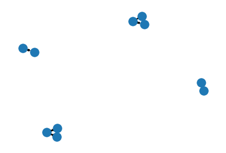

```python
graf = nx.DiGraph(G)
pos = nx.spring_layout(graf)
nx.draw(graf, pos)
```

Graf nie jest spójny, ponieważ są 4 składowe spójne.

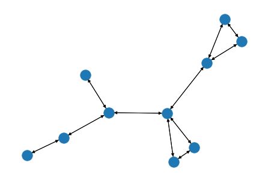

```python
G = uspojnij(G)
graf = nx.DiGraph(G)
pos = nx.spring_layout(graf)
nx.draw(graf, pos)
```

Zatem w przykładowym grafie ze 4 składowymi, dana funkcja także zadziałała prawidłowo, ponieważ otrzymano graf spójny oraz dodano dokładnie 3 krawędzie, by uspójnić graf.

### 4 przykład.

```python
G = np.zeros((30, 30))
for k in range(10):
    for i in range(30):
        for j in range(30):
            if i in set([3 * k, 3 * k + 1, 3 * k + 2]):
                if j in set([3 * k, 3 * k + 1, 3 * k + 2]):
                    G[i, j] = 1
```

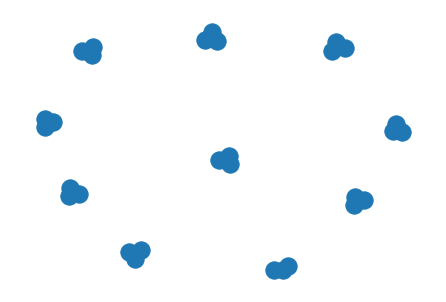

```python
graf = nx.DiGraph(G)
pos = nx.spring_layout(graf)
nx.draw(graf, pos)
```

Graf nie jest spójny, bo jest 10 składowych spójnych.

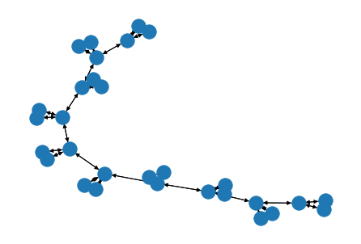

```python
G = uspojnij(G)
graf = nx.DiGraph(G)
pos = nx.spring_layout(graf)
nx.draw(graf, pos)
```

Widać, że funkcja w przypadku tego grafu z 10 składowymi, również poprawnie zadziałała, gdyż otrzymałem graf spójny i dodano minimalną ilość krawędzi, by ten graf uspójnić.

### 5 przykład.

```python
G = np.zeros((75, 75))
for k in range(25):
    for i in range(75):
        for j in range(75):
            if i in set([3 * k, 3 * k + 1, 3 * k + 2]):
                if j in set([3 * k, 3 * k + 1, 3 * k + 2]):
                    G[i, j] = 1
```

[figure not shown]

```python
graf = nx.DiGraph(G)
pos = nx.spring_layout(graf)
nx.draw(graf, pos)
```

Powyższy graf nie jest spójny, bo jest 25 składowych spójnych.

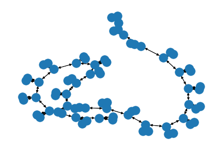

```python
G = uspojnij(G)
graf = nx.DiGraph(G)
pos = nx.spring_layout(graf)
nx.draw(graf, pos)
```

Zatem nawet i w przypadku tego grafu z 25 składowymi, funkcja też prawidłowo zadziałała, ponieważ otrzymałem graf spójny oraz liczba krawędzi dodanych do tego grafu, jest minimalna, by uspójnić graf G.

Ostatecznie, dana funkcja uspójniająca graf, dobrze się sprawdza zarówno w grafach o małej liczbie składowych spójnych, jak i również w grafach, gdzie jest wiele składowych spójnych.